# Intro to Text Mining with Wordclouds

Ian Kloo ian.p.kloo.civ@mail.mil

August 2015

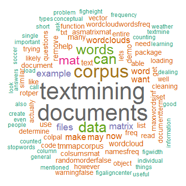

## Introduction

This demo will cover the basics of text mining and creating wordclouds in R (above is a wordcloud based on this document!). After this demo, you should be able to load text-based data into R and create frequency tables and wordclouds. These procedures don’t scratch the surface of the potential capabilities of text mining, but will give you the foundation necessary to apply more advanced techniques.

### What is textmining?

Please forgive the short rant - I promise this demo will actually include some R code. As an intro to text mining, it is necessary to cover a lot of non-code information. And while the code in this demo is short, failing to understand the conceptual framework behind it will make it very hard to understand the results and transition to more difficult analyses. If you are comfortable with the concept of text mining, feel free to skip ahead.

The term “text mining” is thrown around quite a bit without a lot of understanding what it means or implies. Text mining has become a “buzzword” and some people think that just because they have some data in a text format, they will be able to “text mine it”. You may hear these people ask questions that sound like “can you help me text mine this?”

If you hear this question (or think it to yourself!) stop and try to re-frame it. Text mining is a means to an end - a tool. You wouldn’t ask someone, “can you help me table saw this” - you would ask something like, “can you help me cut these 2x4’s with that table saw…I’m making a table.” In the same way, determine exactly what you are trying to accomplish with your text mining task. Text mining is good at answering questions like:

1. What kinds of things are mentioned in these documents?
2. What are the main points (topics) of these documents?
3. Which documents in this stack of documents are similar? What are the similarities?
4. Are people being positive or negative in these documents?
5. What types of things are typically mentioned along with a given topic?

A common theme in all of these questions is counting. Text mining, at its core, is counting. We can do many complex things with our counted data, but it is important to remember what is actually going on behind the scenes. For example, even if we are applying a complex Support Vector Machines algorithm to classify a set of documents, all that we can possibly feed into the algorithm is counted words (with practically few additional metadata variables)! After all, to a computer a document is only a list of words.

Even if you determine that you have one of these questions, it is important to note that **your data may not cooperate**. As with any statistical methodology, it is possible that your specific data cannot be easily, practically, or usefully modeled.

For example, you could use text mining and clustering to determine which documents are similar and different from one another. This, however, may not be possible if the documents you are trying to work with are too similar. Consider this example:

- If you are dealing with documents about either football or boating - text mining/clustering will likely be able to tell these documents apart.
- If you are dealing with documents about NFL season 2013-2014 and NFL season 2014-2015 - text mining/clustering will likely **not** be able to tell these apart.
- Consider a problem you may actually encounter: Text mining is often applied to open ended survey answers, but if the answers to the questions are too similar (say, they are all about the same general topic), you will be fortunate to find any useful results.

Keep these limitations in mind when you are trying to determine whether or not you have a good application for text mining. There are a ton of useful applications of these text mining methodologies, but you need to be careful not to get swept up in the conceptual novelty of “Text Mining.”

OK, now for some actual code:

### Loading Data for Textmining

Loading your data will likely be the biggest headache in any text mining problem. Because analysts are used to dealing with numbers, handling text data can be daunting. Fortunately, there are many R packages that can help. We will use the tm library primarily (short for text miner).

```r
library(tm)
library(wordcloud)
library(Rgraphviz)
library(RColorBrewer)
library(wordcloud)
```

The tm package has methods to read in various file formats, but it does especially well with .txt files. Fortunately, it is easy to save/convert other file types to .txt files. For example, Microsoft Office products, adobe, web browsers, etc. all let you choose to save files as plain text (.txt). You can also text mine very easily from excel files. We will review these 2 data loading procedures below.

#### Loading from .txt files

In text mining, we typically deal with many documents that are stored as their own individual files. We want to read each of these documents into a single collection - called a Corpus - which is essentially a list of documents that stores all of the raw and meta data.

This demo will use a list of documents that I grabbed from the internet. There are 5 weather related documents, 5 political documents, and 7 soccer related documents (5 on the British Premier League and 2 on the German Budesliga).

If you are working with individual files, start by saving them all in a folder by themselves. You can then read all of the files in the folder into your corpus:

```r
source <- DirSource('C:/Users/ian.p.kloo/Documents/TextMiningDemo')
corpus <- Corpus(source, readerControl=list(reader=readPlain))
```

At this point, we have combined all of the “loose” documents into a single, workable object in R. We can now choose whether we want to perform operations over the entire corpus, or single documents within the corpus. For now, we will operate on the entire corpus to do some cleaning.

#### Alternative ways to load data

While text mining usually takes the form of grabbing a bunch of documents to read into R, there are a few other common cases in which this is not practical. For example, you may want to work with the text contents of an excel spreadsheet.

The general procedure for this is to create a vector of the data you are interested in. If you are looking at survey answers, this will likely be a column. You can turn a column (or any vector) into a corpus object by doing the following:

```r
x <- c('test vector')
source2 <- VectorSource(x)
corpus2 <- Corpus(source2)
```

### Cleaning the Data

As mentioned above, counting the number of times a word appears in a document/corpus is the tent pole of text mining. However, in order to count words, we need to do our best to make sure that the words are standardized. For example, we want “Soldier” and “soldier” to be counted as the same word.

The standard procedure is to make everything lowercase, remove numbers, remove punctuation, remove white space, and finally remove stopwords. Stopwords are words such as “the” and “this”. The tm package provides a pre-made list of stopwords - lets take a look at a few of them.

```r
stopwords('english')[1:10]
```

```
##  [1] "i"         "me"        "my"        "myself"    "we"
##  [6] "our"       "ours"      "ourselves" "you"       "your"
```

We can do these cleaning operations over the entire corpus using the tm_map function:

```r
corpus <- tm_map(corpus, content_transformer(tolower))
corpus <- tm_map(corpus, removeNumbers)
corpus <- tm_map(corpus, removePunctuation)
corpus <- tm_map(corpus, stripWhitespace)
corpus <- tm_map(corpus, removeWords, stopwords('english'))
```

You may want to explore additional methods of data cleaning as well. For example, many text miners will stem words (remove ‘ing’,‘ed’,etc.). This works well in many programs, but the tm package does not do particularly well with stemming.

### Manipulate the data

Now that we have clean data, we need to get it into a form that stores counted information. In text mining we call this a document-term matrix (or term-document matrix). In this structure, a row is a document and a column is a term. The values in the matrix are frequency counts (how many times a word appears in a document).

The tm package has the DocumentTermMatrix function which does the heavy lifting for us:

```r
mat <- DocumentTermMatrix(corpus)
mat
```

```
## <<DocumentTermMatrix (documents: 17, terms: 3174)>>
## Non-/sparse entries: 5035/48923
## Sparsity           : 91%
## Maximal term length: 21
## Weighting          : term frequency (tf)
```

As you can see, calling our document-term matrix gives us some summary information, but does not give us the actual matrix I described above. The output of the above function is another R object that is a list of metadata and the true document-term matrix. To get what we actually want, we can just call matrix() on this object.

```r
mat2 <- as.matrix(mat)
mat2[1:10,6:11]
```

```
##           Terms
## Docs       absolutely autopsy birth birthright black colored
##   DBL1.txt           0         0      0           0      0        0
##   DBL2.txt           0         0      0           0      0        0
##   EPL1.txt           0         0      0           0      0        0
##   EPL2.txt           0         0      0           0      0        0
##   EPL3.txt           0         0      0           0      0        0
##   EPL4.txt           0         0      0           0      0        0
##   EPL5.txt           0         0      0           0      0        0
##   POL1.txt           1         1      0           1      0        0
##   POL2.txt           0         0      0           0      0        0
##   POL3.txt           0         0      1           0      1        1
```

Now we have what we wanted and can move on to the visualization.

### Create a wordcloud

We have all seen wordclouds - they are visualizations that represent words where size/color correspond to frequency of use. We will use the wordcloud package to make our wordclouds.

First, lets make a wordcloud based on the entire corpus:

The wordcloud() function takes 2 vectors as arguments: words and frequencies. Lets split those out of the document-term matrix we made before:

```r
freq <- colSums(mat2)
words <- names(freq)
```

We also will want to specify a color scheme:

```r
pal2 <- brewer.pal(8, 'Dark2')
```

Now we call the wordcloud:

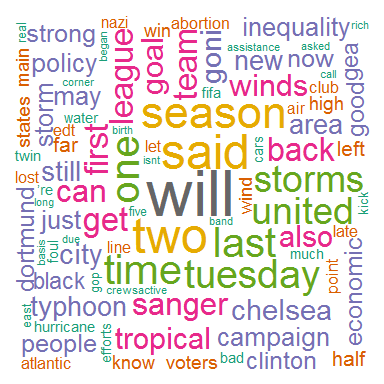

```r
wordcloud(words,freq, col=pal2, random.order=FALSE, rot.per=.15, max.words=Inf)
```

This looks pretty good - except “will” is prominently featured. This doesn’t seem like a very informative word to me, so I’m going to drop it. This is where the art of text mining comes into play. In some cases, words like “will” could be very important to a text mining problem. For example, you may train a classifier that divides documents based on their use of future, present, or past tense words. In this case, however, I will remove the word for aesthetics.

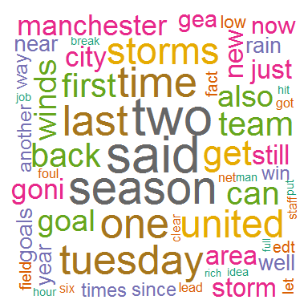

```r
corpus <- tm_map(corpus, removeWords, 'will')

mat <- DocumentTermMatrix(corpus)
mat2 <- as.matrix(mat)

freq <- colSums(mat2)
words <- names(freq)

wordcloud(words,freq, col=pal2, random.order=FALSE, rot.per=.15, max.words=Inf)
```

This gives us a look at what is being said in the corpus, but what about the individual documents? Lets take a look at the soccer, weather, and political documents separately.

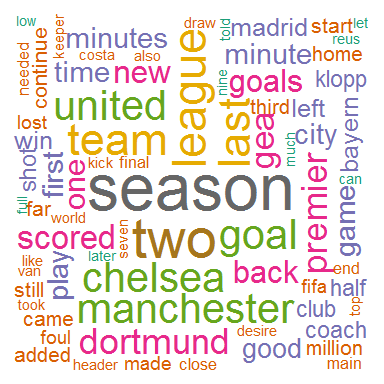

```r
soccer <- corpus[1:7]
politics <- corpus[8:12]
weather <- corpus[13:17]

mat <- DocumentTermMatrix(soccer)
mat2 <- as.matrix(mat)

freq <- colSums(mat2)
words <- names(freq)

wordcloud(words,freq, col=pal2, random.order=FALSE, rot.per=.15, max.words=Inf)
```

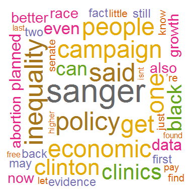

```r
mat <- DocumentTermMatrix(politics)
mat2 <- as.matrix(mat)

freq <- colSums(mat2)
words <- names(freq)

wordcloud(words,freq, col=pal2, random.order=FALSE, rot.per=.15, max.words=Inf)
```

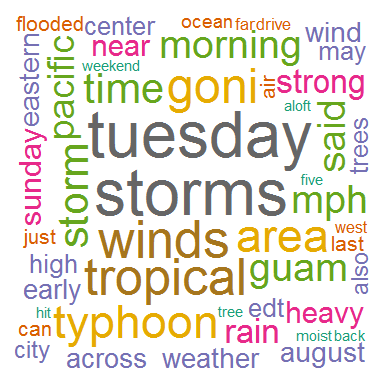

```r
mat <- DocumentTermMatrix(weather)
mat2 <- as.matrix(mat)

freq <- colSums(mat2)
words <- names(freq)

wordcloud(words,freq, col=pal2, random.order=FALSE, rot.per=.15, max.words=Inf)
```

Now, it is pretty clear which wordcloud belongs to which set of documents (even without looking at the code). This demonstrates that wordclouds can be very useful when trying to get the general idea of what is being discussed in a document or corpus, but it also demonstrates the need for analytic thinking in text mining:

The corpus-level wordcloud is all but meaningless in that we cannot draw any real conclusions other than the fact that all of the documents are written in english. After further processing, however, we were able to make a set of wordclouds that help differentiate between the types of documents in the corpus.

### Conclusion

This demo discussed the conceptual framework of text mining, showed how to load text data into R, demonstrated how to make a document-term matrix, and showed how to make wordclouds in R. The next step in learning text mining is learning how to apply machine learning algorithms to help differentiate and/or draw similarities between documents. This will be covered in a set of follow-on tutorials.